# Regression_age_mG1

kithsiri Jayakody

12/6/2020

## R Markdown

Question: there is a relationship between mG1 score and the pG1? .

Hypothesis (Two-tailed)

H0: There are no relationship between maths first grade score and protuguese first grade score HA: There is a relationship between maths first grade score and protuguese first grade score

as the first step need to load the dataset

```r
setwd('D:/statistics')
# dataset is loading and converting the character based data types to factors
df = read.csv('sperformance-dataset.csv',stringsAsFactors = F)

# converting the character type into factorial variables and see the conversion
indices <- c(1,2,4:6,9:14,18:23,34,38:43)

for(i in indices)
{
  df[[i]] <- as.factor(df[[i]])
}
```

following code block is used to load the required files.

```r
needed_packages <- c("foreign", "stats", "lm.beta", "stargazer", "ggplot2")
# Extract not installed packages
not_installed <- needed_packages[!(needed_packages %in% installed.packages()[ , "Package"])]
# Install not installed packages
if(length(not_installed)) install.packages(not_installed)

library(stats)
library(ggplot2)
library(foreign) #To work with SPSS data
library(lm.beta) #Will allow us to isolate the beta co-efficients
library(stargazer)#For formatting outputs/tables
```

following code block is used to test the normal distribution of the variable mg1

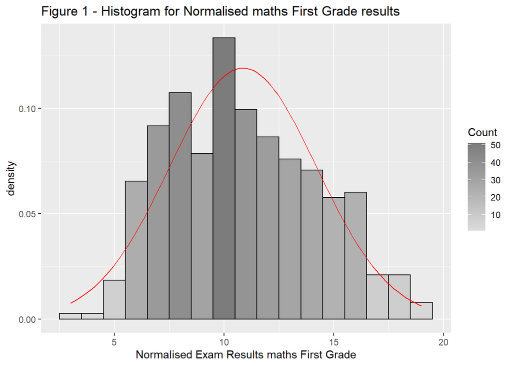

```r
#We will allocate the histogram to a variable to allow use to manipulate it
gg <- ggplot(df, aes(x=df$mG1))
gg <- gg+ggtitle("Figure 1 - Histogram for Normalised maths First Grade results")
gg <- gg + labs(x="Normalised Exam Results maths First Grade")
#manage binwidth and colours
gg <- gg + geom_histogram(binwidth=1, colour="black", aes(y=..density.., fill=..count..))
gg <- gg + scale_fill_gradient("Count", low="#DCDCDC", high="#7C7C7C")
#adding a normal curve
#use stat_function to compute a normalised score for each value of normexam
#pass the mean and standard deviation
#use the na.rm parameter to say how missing values are handled
gg <- gg + stat_function(fun=dnorm, color="red",args=list(mean=mean(df$mG1, na.rm=TRUE), sd=sd(df$mG1, na.rm=TRUE)))

#to display the graph request the contents of the variable be shown
gg
```

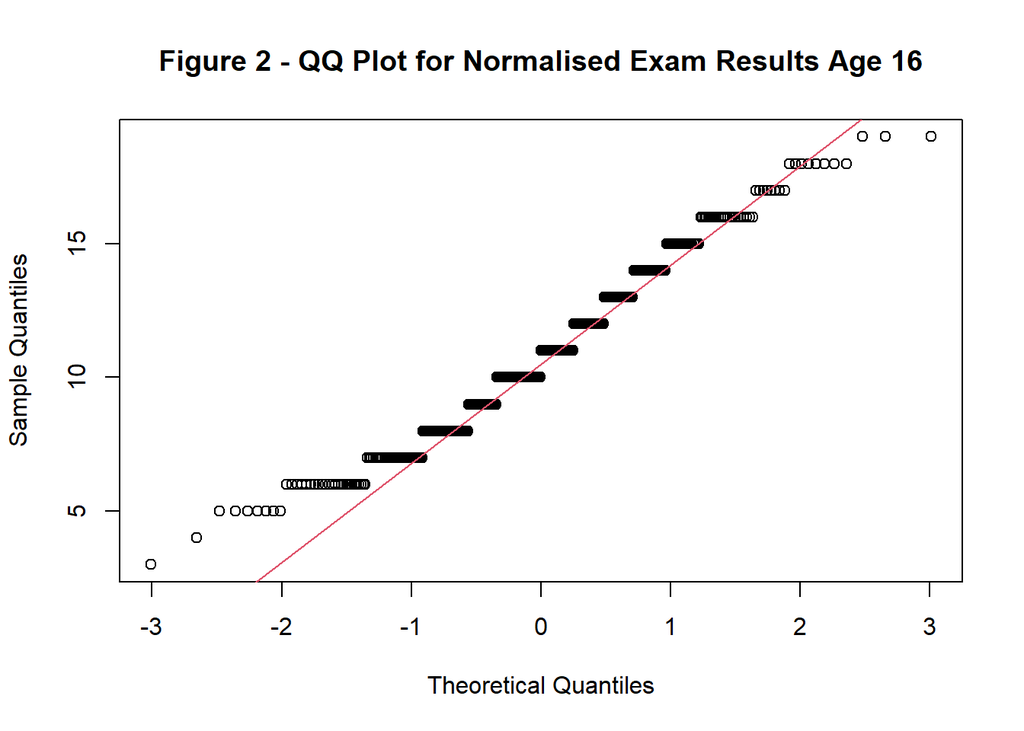

```r
#Create a qqplot
qqnorm(df$mG1, main="Figure 2 - QQ Plot for Normalised Exam Results Age 16")
qqline(df$mG1, col=2) #show a line on the plot
```

```r
#Get summary statistics - we know it the variable is normal so we will go ahead with it
mean(df$mG1)
```

```
## [1] 10.86126
```

```r
sd(df$mG1)
```

```
## [1] 3.349167
```

```r
length(df$mG1)
```

```
## [1] 382
```

```r
#We can make our decision based on the value of the standardised score for skew and kurtosis
#We divide the skew statistic by the standard error to get the standardised score
#This will indicate if we have a problem
tpskew<-semTools::skew(df$mG1)
tpkurt<-semTools::kurtosis(df$mG1)
tpskew[1]/tpskew[2]
```

```
## skew (g1)
##  2.205097
```

```r
tpkurt[1]/tpkurt[2]
```

```
## Excess Kur (g2)
##       -2.742249
```

```r
#checked standardise the scores

#and by calculating the percentage of standardised scores for the variable itself that are outside our acceptable range
#This will tell us how big a problem we have
# Calculate the percentage of standardised scores that are greated than 1.96
# the perc function which is part of the FSA package which calculate the percentage that are within a range - you can look for greater than "gt", greater than or equal "geq", "gt", less than or equal "leq",  or less than "lt"),
# scale is a function that creates z scores, abs gets absolute value

ztotsas<- abs(scale(df$mG1))

FSA::perc(as.numeric(ztotsas), 1.96, "gt")
```

```
## [1] 3.403141
```

```r
FSA::perc(as.numeric(ztotsas), 3.29, "gt")
```

```
## [1] 0
```